# Río Mana: granulometría superficial mediante SfM y SegmentEveryGrain

Bitácora reproducible — inventario reconstruido, morfometría, variabilidad espacial y validación de campo

Equipo de investigación

13/11/2026

# 1 Alcance y decisiones metodológicas

Este cuaderno analiza **el inventario final de clastos reconstruidos**. El archivo `granos_mana_final.gpkg` procede del script independiente `fusion_SEG_inventario_final_corregido.R`, que ya ejecutó las fusiones manuales, reparó geometrías puntuales, vinculó los puntos de campo y recalculó los ejes completos de una **elipse equivalente por momentos de área**. **Aquí no se repite ninguna fusión ni se recalculan los ejes**: se leen los resultados validados del proceso anterior. El GeoPackage original permanece intacto.

No se excluyen clastos por el campo `toca_borde`: la posición en la tesela no es un criterio de exclusión. Los percentiles corresponden a **frecuencias por número de clastos**, no a porcentajes de masa. Los ejes de elipse equivalente son medidas bidimensionales y no son necesariamente idénticos a las medidas sedimentológicas tomadas manualmente.

# 2 1. Lectura del inventario definitivo y control de calidad

```r
if (!file.exists(GPKG)) stop('No existe ',GPKG,
  '. Ejecute primero el script de reconstrucción desde la raíz del proyecto.')
capas <- sf::st_layers(GPKG)$name
if (!'inventario_final' %in% capas)
  stop('Falta la capa inventario_final en ',GPKG)
poligonos <- sf::st_read(GPKG,layer='inventario_final',quiet=TRUE)
if (sf::st_crs(poligonos)$epsg != EPSG)
  stop('CRS inesperado; se requiere EPSG:',EPSG)
requeridas <- c('uid_final','n_fragmentos','a_seg_mm','b_seg_mm',
               'area_seg_m2','perimetro_seg_m','razon_ba_seg',
               'id_campo','a_campo_mm','b_campo_mm')
faltantes <- setdiff(requeridas,names(poligonos))
if (length(faltantes)) stop('Faltan campos: ',paste(faltantes,collapse=', '))
if (anyDuplicated(poligonos$uid_final)) stop('uid_final duplicado')
if (any(sf::st_is_empty(poligonos))) stop('Inventario final contiene geometrías vacías')
if (any(!sf::st_is_valid(poligonos))) stop('Inventario final contiene geometrías inválidas')
# Punto interior garantizado para representación; no modifica las geometrías.
centros <- suppressWarnings(sf::st_coordinates(sf::st_point_on_surface(poligonos)))
datos <- sf::st_drop_geometry(poligonos) %>%
  mutate(x_utm=centros[,1],y_utm=centros[,2],
         a_mm=as.numeric(a_seg_mm),b_mm=as.numeric(b_seg_mm),
         area_mm2=as.numeric(area_seg_m2)*1e6,
         perimetro_mm=as.numeric(perimetro_seg_m)*1000,
         razon_ba=as.numeric(razon_ba_seg),
         circularidad=4*pi*as.numeric(area_seg_m2)/
           (as.numeric(perimetro_seg_m)^2),
         qc_valida=is.finite(a_mm)&is.finite(b_mm)&
           is.finite(area_mm2)&a_mm>=b_mm&b_mm>0&area_mm2>0)
principal <- datos %>% filter(qc_valida)
if (!nrow(principal)) stop('No hay clastos con dimensiones válidas')
qc <- tibble(indicador=c('Clastos finales','Dimensiones válidas',
                         'Clastos fusionados','Clastos individuales',
                         'Clastos vinculados a campo'),
             n=c(nrow(datos),nrow(principal),
                 sum(datos$n_fragmentos>1,na.rm=TRUE),
                 sum(datos$n_fragmentos==1,na.rm=TRUE),
                 sum(!is.na(datos$id_campo))))
knitr::kable(qc)
```

| indicador | n |
| --- | --- |
| Clastos finales | 45013 |
| Dimensiones válidas | 45013 |
| Clastos fusionados | 295 |
| Clastos individuales | 44718 |
| Clastos vinculados a campo | 73 |

```r
guardar_csv(qc,'control_calidad_final.csv')
```

El inventario contiene **45.013 clastos**, de los que **295** proceden de la unión de varios fragmentos SEG. No se ha filtrado por bordes de tesela.

## 2.1 1.1. Trazabilidad de las fusiones

```r
if (file.exists(TRAZA)) {
  traza <- readr::read_csv(TRAZA,show_col_types=FALSE)
  resumen_traza <- tibble(
    poligonos_seg_originales=nrow(traza),
    clastos_finales=n_distinct(traza$uid_final),
    reduccion=nrow(traza)-n_distinct(traza$uid_final))
  knitr::kable(resumen_traza)
  guardar_csv(resumen_traza,'resumen_reconstruccion.csv')
} else {
  cat('No se encontró el CSV de trazabilidad; se omite esta auditoría.\n')
}
```

# 3 2. Distribución granulométrica superficial

```r
cuantiles <- function(d,etiqueta='Inventario final') {
  qs <- qseg(d$b_mm)
  tibble(conjunto=etiqueta,n=nrow(d),D10=qs[1],D16=qs[2],
         D50=qs[3],D84=qs[4],D90=qs[5],
         sorting_ratio=qs[4]/qs[2],
         sorting_geometrico=sqrt(qs[4]/qs[2]))
}
resumen_q <- cuantiles(principal)
knitr::kable(resumen_q,digits=2)
```

| conjunto | n | D10 | D16 | D50 | D84 | D90 | sorting_ratio | sorting_geometrico |
| --- | --- | --- | --- | --- | --- | --- | --- | --- |
| Inventario final | 45013 | 18.26 | 20.27 | 32.73 | 69.09 | 88.76 | 3.41 | 1.85 |

```r
guardar_csv(resumen_q,'percentiles_conteo_final.csv')
resumen_inventario <- principal %>% summarise(
  n_clastos=n(),n_fusionados=sum(n_fragmentos>1),
  a_mediana_mm=median(a_mm),b_mediana_mm=median(b_mm),
  a_media_mm=mean(a_mm),b_media_mm=mean(b_mm),
  a_p95_mm=unname(quantile(a_mm,.95)),
  b_p95_mm=unname(quantile(b_mm,.95)),
  relacion_ba_mediana=median(razon_ba))
knitr::kable(resumen_inventario,digits=2)
```

| n_clastos | n_fusionados | a_mediana_mm | b_mediana_mm | a_media_mm | b_media_mm | a_p95_mm | b_p95_mm | relacion_ba_mediana |
| --- | --- | --- | --- | --- | --- | --- | --- | --- |
| 45013 | 295 | 52.41 | 32.73 | 74.56 | 46.6 | 198.6 | 122.2 | 0.67 |

```r
guardar_csv(resumen_inventario,'resumen_inventario.csv')
```

La mediana del eje menor es **32.73 mm** y el percentil D84 es **69.09 mm**. Estas magnitudes corresponden al eje menor de la elipse equivalente, por número de clastos.

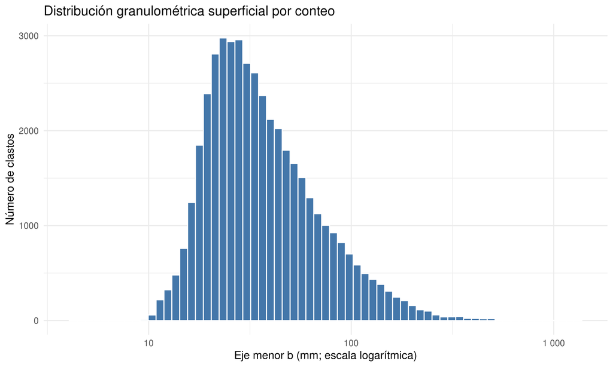

```r
p_hist <- ggplot(principal,aes(b_mm))+
  geom_histogram(bins=65,fill='#4477AA',color='white')+
  scale_x_log10(labels=scales::label_number())+
  labs(x='Eje menor b (mm; escala logarítmica)',y='Número de clastos',
       title='Distribución granulométrica superficial por conteo')+tema
exportar(p_hist,'02_histograma_b_log')
```

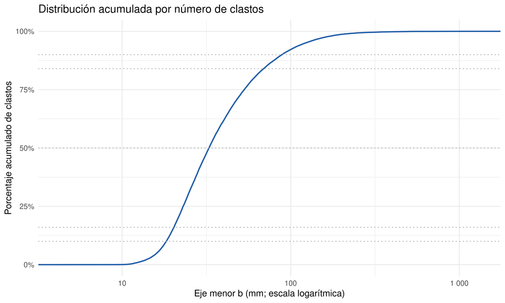

```r
p_cum <- ggplot(principal,aes(b_mm))+
  stat_ecdf(geom='step',linewidth=.9,color='#225EA8')+
  scale_x_log10(labels=scales::label_number())+
  scale_y_continuous(labels=scales::label_percent())+
  geom_hline(yintercept=c(.1,.16,.5,.84,.9),linetype='dotted',color='grey65')+
  labs(x='Eje menor b (mm; escala logarítmica)',
       y='Porcentaje acumulado de clastos',
       title='Distribución acumulada por número de clastos')+tema
exportar(p_cum,'03_curva_acumulada')
```

## 3.1 2.1. Sensibilidad al umbral inferior de tamaño

El análisis siguiente examina el efecto de imponer distintos umbrales de inclusión. **No evalúa bordes** y **no estima eficiencia de detección**.

```r
umbrales <- c(10,15,20,25)
sens <- purrr::map_dfr(umbrales,function(u) {
  cuantiles(principal %>% filter(b_mm>=u)) %>%
    mutate(umbral_mm=u)
})
knitr::kable(sens,digits=2)
```

| conjunto | n | D10 | D16 | D50 | D84 | D90 | sorting_ratio | sorting_geometrico | umbral_mm |
| --- | --- | --- | --- | --- | --- | --- | --- | --- | --- |
| Inventario final | 44992 | 18.28 | 20.28 | 32.74 | 69.11 | 88.77 | 3.41 | 1.85 | 10 |
| Inventario final | 43503 | 19.31 | 21.12 | 33.59 | 70.49 | 90.16 | 3.34 | 1.83 | 15 |
| Inventario final | 38199 | 22.59 | 24.22 | 37.01 | 75.62 | 96.13 | 3.12 | 1.77 | 20 |
| Inventario final | 30999 | 27.50 | 29.10 | 43.01 | 84.47 | 105.83 | 2.90 | 1.70 | 25 |

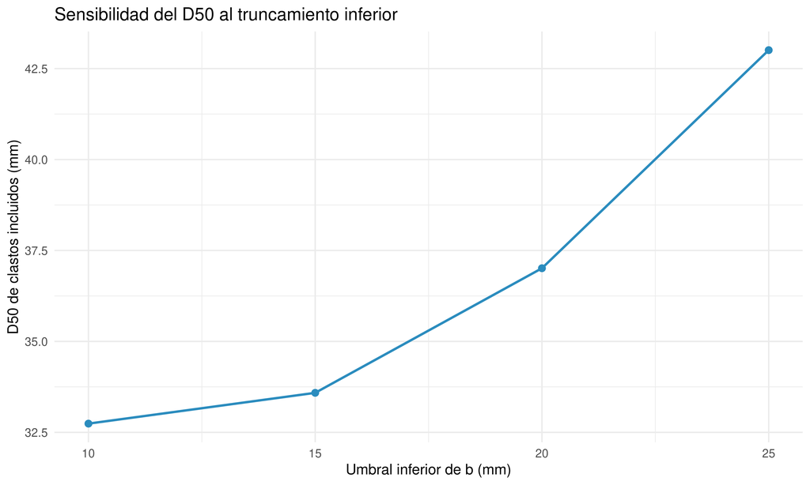

```r
guardar_csv(sens,'sensibilidad_umbral_tamano.csv')
p_sens <- ggplot(sens,aes(umbral_mm,D50))+
  geom_line(color='#2B8CBE',linewidth=1)+
  geom_point(color='#2B8CBE',size=2.5)+
  labs(x='Umbral inferior de b (mm)',y='D50 de clastos incluidos (mm)',
       title='Sensibilidad del D50 al truncamiento inferior')+tema
exportar(p_sens,'04_sensibilidad_D50')
```

# 4 3. Morfometría proyectada

```r
forma <- principal %>% summarise(
  n=n(),a_mediana_mm=median(a_mm),b_mediana_mm=median(b_mm),
  razon_ba_mediana=median(razon_ba),
  circularidad_mediana=median(circularidad[is.finite(circularidad)]),
  spearman_tamano_forma=cor(b_mm,razon_ba,method='spearman'))
knitr::kable(forma,digits=3)
```

| n | a_mediana_mm | b_mediana_mm | razon_ba_mediana | circularidad_mediana | spearman_tamano_forma |
| --- | --- | --- | --- | --- | --- |
| 45013 | 52.41 | 32.73 | 0.666 | 0.767 | 0.099 |

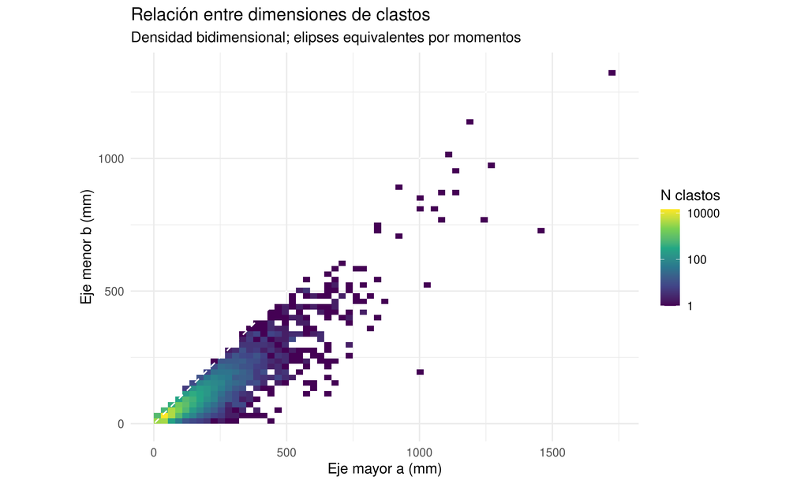

```r
guardar_csv(forma,'morfometria_resumen.csv')
# Recupera el gráfico de densidad coloreado del cuaderno original.
p_ab <- ggplot(principal,aes(a_mm,b_mm))+
  geom_bin2d(bins=65)+
  scale_fill_viridis_c(trans='log10')+
  geom_abline(slope=1,intercept=0,linetype='dashed',color='white')+
  coord_equal()+
  labs(x='Eje mayor a (mm)',y='Eje menor b (mm)',
       title='Relación entre dimensiones de clastos',
       subtitle='Densidad bidimensional; elipses equivalentes por momentos',
       fill='N clastos')+tema
exportar(p_ab,'05_relacion_ejes',10,7)
```

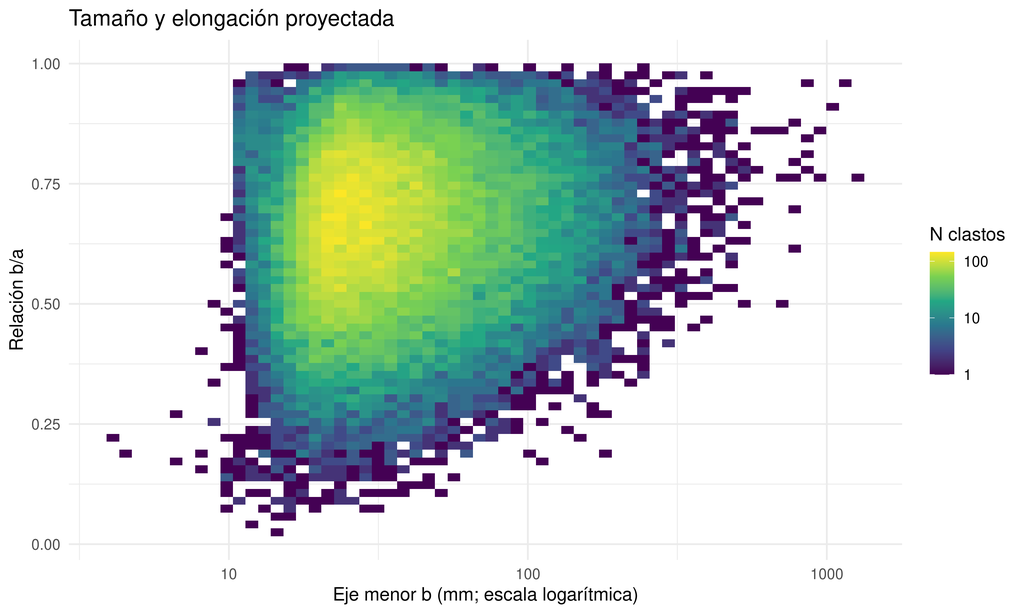

```r
# geom_bin2d no requiere el paquete adicional hexbin.
p_forma <- ggplot(principal %>%
                     filter(is.finite(razon_ba),razon_ba>0,razon_ba<=1),
                   aes(b_mm,razon_ba))+
  geom_bin2d(bins=60)+
  scale_fill_viridis_c(trans='log10')+
  scale_x_log10()+
  labs(x='Eje menor b (mm; escala logarítmica)',
       y='Relación b/a',fill='N clastos',
       title='Tamaño y elongación proyectada')+tema
exportar(p_forma,'06_tamano_elongacion')
```

El cociente b/a representa elongación bidimensional; no mide esfericidad tridimensional. La circularidad depende de la irregularidad del contorno.

# 5 4. Distribución espacial y heterogeneidad

Los mapas emplean coordenadas EPSG:32619 y una cuadrícula UTM fija. Las posiciones corresponden a puntos interiores de las geometrías reconstruidas. Los valores por celda se calculan únicamente con clastos presentes; no se interpolan zonas sin detecciones.

```r
puntos_finales <- sf::st_as_sf(principal,coords=c('x_utm','y_utm'),
                              crs=EPSG,remove=FALSE)
f_cent <- file.path(DIR_TAB,'centroides_finales.gpkg')
if (!file.exists(f_cent)) {
  sf::st_write(puntos_finales,f_cent,layer='centroides',quiet=TRUE)
} else {
  message('Se conserva el GeoPackage de centroides existente: ',f_cent)
}
res_celda <- principal %>%
  mutate(cx=floor(x_utm/CELDA_M),cy=floor(y_utm/CELDA_M)) %>%
  group_by(cx,cy) %>%
  summarise(n=n(),D50=median(b_mm),
            D84=unname(quantile(b_mm,.84)),
            b_media=mean(b_mm),ba_mediana=median(razon_ba),
            .groups='drop') %>%
  mutate(x=(cx+.5)*CELDA_M,y=(cy+.5)*CELDA_M,
         suficiente=n>=MIN_N_CELDA)
guardar_csv(res_celda,'resumen_celdas_final.csv')
knitr::kable(res_celda %>% summarise(
  celdas=n(),celdas_suficientes=sum(suficiente),
  mediana_clastos_celda=median(n)))
```

| celdas | celdas_suficientes | mediana_clastos_celda |
| --- | --- | --- |
| 365 | 313 | 104 |

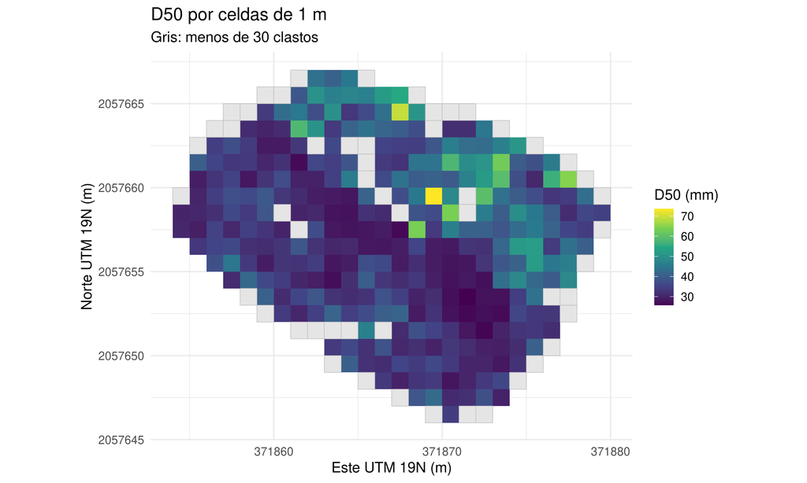

```r
p_mapa <- ggplot(res_celda,aes(x,y))+
  geom_tile(data=filter(res_celda,suficiente),aes(fill=D50),
            width=CELDA_M,height=CELDA_M)+
  geom_tile(data=filter(res_celda,!suficiente),
            fill='grey90',color='grey75',
            width=CELDA_M,height=CELDA_M)+
  coord_equal()+scale_fill_viridis_c(na.value='grey90')+
  labs(x='Este UTM 19N (m)',y='Norte UTM 19N (m)',fill='D50 (mm)',
       title=paste0('D50 por celdas de ',CELDA_M,' m'),
       subtitle=paste('Gris: menos de',MIN_N_CELDA,'clastos'))+tema
exportar(p_mapa,'07_mapa_D50',10,7)
```

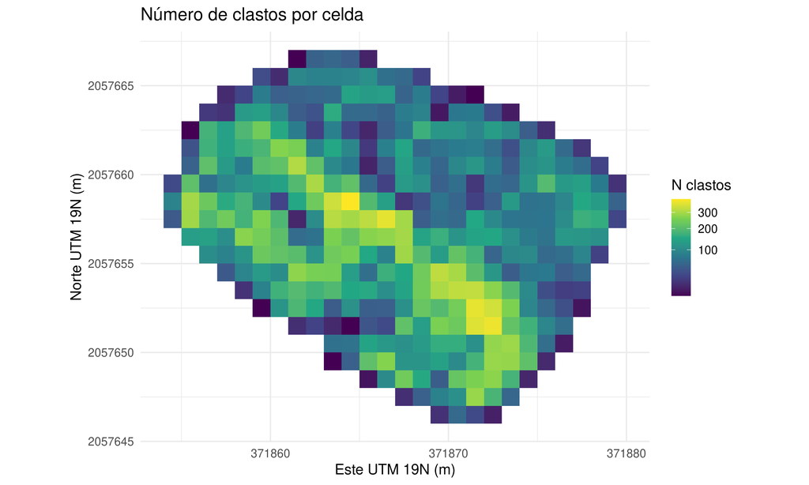

```r
p_n <- ggplot(res_celda,aes(x,y,fill=n))+
  geom_tile(width=CELDA_M,height=CELDA_M)+
  coord_equal()+scale_fill_viridis_c(trans='sqrt')+
  labs(x='Este UTM 19N (m)',y='Norte UTM 19N (m)',fill='N clastos',
       title='Número de clastos por celda')+tema
exportar(p_n,'08_mapa_recuento',10,7)
```

## 5.1 4.1. Variación entre teselas (descriptiva)

Para clastos fusionados, `tesela` es el atributo heredado de un fragmento; por ello, este agrupamiento es **operativo** y no representa necesariamente la distribución exacta de cada clasto entre teselas.

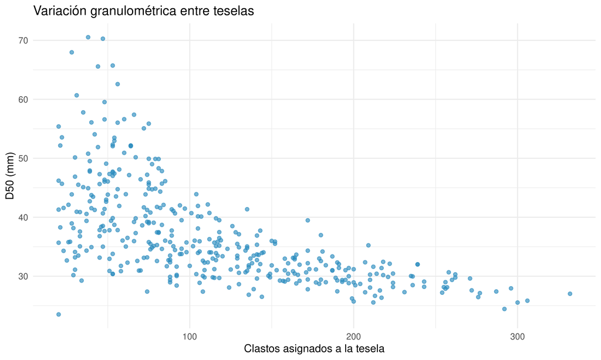

```r
if ('tesela' %in% names(principal)) {
  res_tes <- principal %>% filter(!is.na(tesela)) %>%
    group_by(tesela) %>%
    summarise(n=n(),D50=median(b_mm),
              D84=unname(quantile(b_mm,.84)),
              ba_mediana=median(razon_ba),.groups='drop')
  guardar_csv(res_tes,'resumen_teselas_final.csv')
  p_tes <- res_tes %>% filter(n>=MIN_N_TESELA) %>%
    ggplot(aes(n,D50))+geom_point(alpha=.65,color='#2B8CBE')+
    labs(x='Clastos asignados a la tesela',y='D50 (mm)',
         title='Variación granulométrica entre teselas')+tema
  exportar(p_tes,'09_D50_teselas')
} else cat('No hay atributo tesela; se omite este análisis.\n')
```

## 5.2 4.2. Remuestreo exploratorio por teselas

Los intervalos reflejan variación entre bloques operativos, **no** exactitud de segmentación ni incertidumbre para toda la llanura.

```r
if ('tesela' %in% names(principal)) {
  bloques <- split(principal$b_mm,principal$tesela)
  bloques <- bloques[lengths(bloques)>0]
  if (length(bloques)>=3) {
    boot <- replicate(B_REP,{
      ids <- sample(seq_along(bloques),length(bloques),replace=TRUE)
      qseg(unlist(bloques[ids],use.names=FALSE),c(.5,.84))
    })
    ic <- tibble(metrica=c('D50','D84'),
      estimacion=qseg(principal$b_mm,c(.5,.84)),
      inf=apply(boot,1,quantile,probs=.025,na.rm=TRUE),
      sup=apply(boot,1,quantile,probs=.975,na.rm=TRUE),
      n_bloques=length(bloques))
    knitr::kable(ic,digits=2)
    guardar_csv(ic,'intervalos_bootstrap_teselas.csv')
  } else cat('No hay suficientes teselas para remuestreo.\n')
}
```

# 6 5. Validación de campo frente a SegmentEveryGrain

La vinculación de campo ya se realizó espacialmente **después de fusionar** las geometrías. Se comparan por separado los ejes mayores y menores. Una correlación alta indica asociación lineal, pero **no basta para demostrar concordancia**; se informan además sesgo, MAE, RMSE y MAPE.

```r
val <- principal %>% filter(!is.na(id_campo),
  is.finite(a_campo_mm),is.finite(b_campo_mm),
  a_campo_mm>0,b_campo_mm>0)
if (nrow(val)<3) stop('Menos de tres pares de campo válidos')
comparacion <- dplyr::bind_rows(
  val %>% transmute(id_campo,eje='a',
                    campo_mm=a_campo_mm,seg_mm=a_mm),
  val %>% transmute(id_campo,eje='b',
                    campo_mm=b_campo_mm,seg_mm=b_mm)) %>%
  mutate(error_mm=seg_mm-campo_mm,
         error_abs_mm=abs(error_mm),
         error_pct=100*error_mm/campo_mm,
         media_par=(seg_mm+campo_mm)/2)
resumen_validacion <- comparacion %>% group_by(eje) %>%
  summarise(n=n(),sesgo_mm=mean(error_mm),
    MAE_mm=mean(error_abs_mm),RMSE_mm=sqrt(mean(error_mm^2)),
    MAPE_pct=mean(abs(error_pct)),
    correlacion=cor(campo_mm,seg_mm),
    r2=correlacion^2,
    .groups='drop')
knitr::kable(resumen_validacion,digits=3)
```

| eje | n | sesgo_mm | MAE_mm | RMSE_mm | MAPE_pct | correlacion | r2 |
| --- | --- | --- | --- | --- | --- | --- | --- |
| a | 73 | 10.333 | 16.15 | 23.08 | 6.072 | 0.996 | 0.993 |
| b | 73 | -1.618 | 13.14 | 28.16 | 5.827 | 0.989 | 0.979 |

```r
guardar_csv(resumen_validacion,'resumen_validacion.csv')
guardar_csv(comparacion,'pares_validacion.csv')
```

Se emparejaron **73 clastos**. La correlación de Pearson fue **0.996** para el eje mayor y **0.989** para el eje menor. La diferencia media SEG–campo fue de **10.33 mm** para `a` y **-1.62 mm** para `b`.

```r
# Estadísticos calculados por eje, directamente de los pares validados.
# R² es el coeficiente de determinación de una regresión OLS con intercepto.
estadisticas_cor <- comparacion %>%
  group_by(eje) %>%
  summarise(
    n=n(),
    r=cor(campo_mm,seg_mm),
    r2=r^2,
    pendiente=unname(coef(lm(seg_mm~campo_mm))[2]),
    intercepto=unname(coef(lm(seg_mm~campo_mm))[1]),
    .groups='drop'
  ) %>%
  mutate(
    etiqueta=sprintf(
      'n = %d\nr = %.4f\nR² = %.4f\nSEG = %.3f + %.3f × campo',
      n,r,r2,intercepto,pendiente
    )
  )
knitr::kable(estadisticas_cor,digits=4)
```

[output not shown]

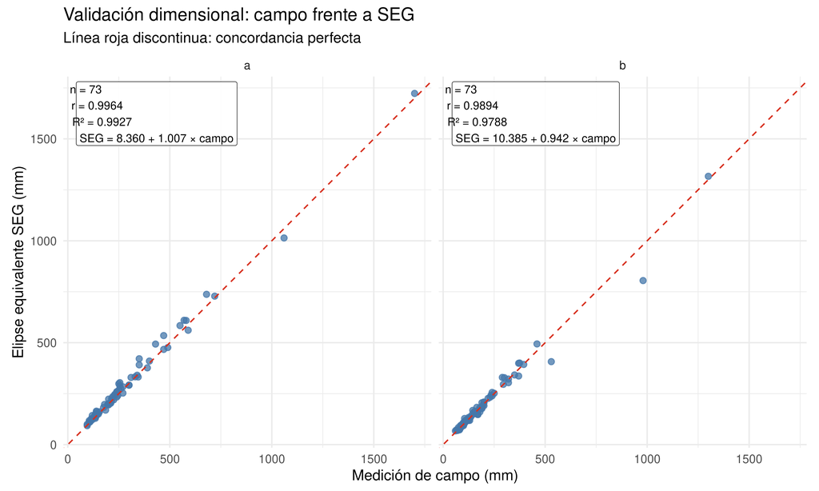

```r
guardar_csv(estadisticas_cor,'estadisticas_correlacion.csv')

p_val <- ggplot(comparacion,aes(campo_mm,seg_mm))+
  geom_point(color='#4477AA',alpha=.75,size=2.2)+
  geom_abline(slope=1,intercept=0,linetype='dashed',color='#D7301F')+
  geom_label(data=estadisticas_cor,
             aes(x=-Inf,y=Inf,label=etiqueta),
             inherit.aes=FALSE,hjust=-.08,vjust=1.08,
             size=3.5,label.size=.2,fill='white',alpha=.92)+
  facet_wrap(~eje,scales='fixed')+coord_equal()+
  labs(x='Medición de campo (mm)',y='Elipse equivalente SEG (mm)',
       title='Validación dimensional: campo frente a SEG',
       subtitle='Línea roja discontinua: concordancia perfecta')+tema
exportar(p_val,'11_validacion_campo_SEG',11,7)
```

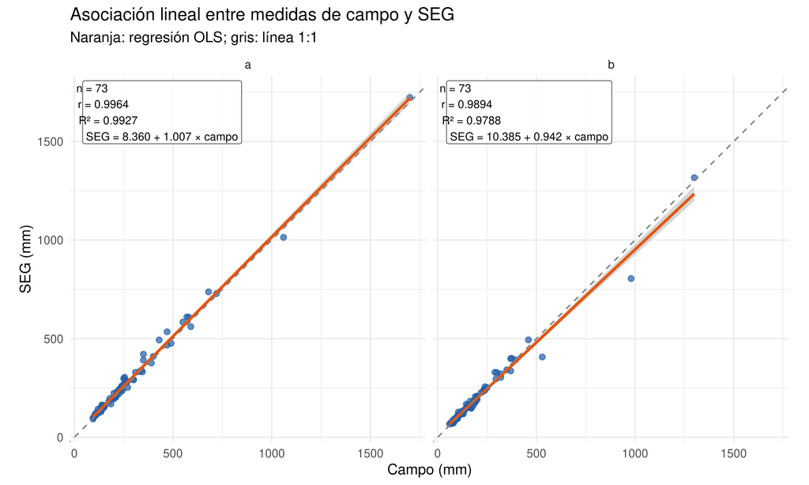

```r
p_cor <- ggplot(comparacion,aes(campo_mm,seg_mm))+
  geom_point(color='#225EA8',alpha=.7,size=2.1)+
  geom_smooth(method='lm',formula=y~x,se=TRUE,color='#E6550D')+
  geom_abline(slope=1,intercept=0,linetype='dashed',color='grey50')+
  geom_label(data=estadisticas_cor,
             aes(x=-Inf,y=Inf,label=etiqueta),
             inherit.aes=FALSE,hjust=-.08,vjust=1.08,
             size=3.5,label.size=.2,fill='white',alpha=.92)+
  facet_wrap(~eje,scales='fixed')+coord_equal()+
  labs(x='Campo (mm)',y='SEG (mm)',
       title='Asociación lineal entre medidas de campo y SEG',
       subtitle='Naranja: regresión OLS; gris: línea 1:1')+tema
exportar(p_cor,'12_correlacion_campo_SEG',11,7)
```

## 6.1 5.1. Diferencias y concordancia (Bland–Altman)

Los límites ±1,96 DE son descriptivos y dependen de los supuestos habituales del método; no sustituyen la inspección de valores atípicos ni la evaluación de sesgo proporcional.

```r
limites <- comparacion %>% group_by(eje) %>%
  summarise(sesgo=mean(error_mm),de=sd(error_mm),
            inferior=sesgo-1.96*de,superior=sesgo+1.96*de,
            .groups='drop')
knitr::kable(limites,digits=2)
```

| eje | sesgo | de | inferior | superior |
| --- | --- | --- | --- | --- |
| a | 10.33 | 20.78 | -30.39 | 51.06 |
| b | -1.62 | 28.31 | -57.10 | 53.87 |

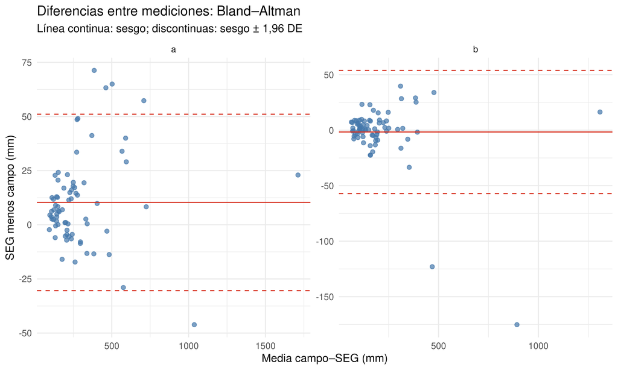

```r
guardar_csv(limites,'limites_concordancia.csv')
p_ba <- ggplot(comparacion,aes(media_par,error_mm))+
  geom_point(color='#4477AA',alpha=.7,size=2)+
  geom_hline(data=limites,aes(yintercept=sesgo),color='#D7301F')+
  geom_hline(data=limites,aes(yintercept=inferior),
             color='#D7301F',linetype='dashed')+
  geom_hline(data=limites,aes(yintercept=superior),
             color='#D7301F',linetype='dashed')+
  facet_wrap(~eje,scales='free')+
  labs(x='Media campo–SEG (mm)',y='SEG menos campo (mm)',
       title='Diferencias entre mediciones: Bland–Altman',
       subtitle='Línea continua: sesgo; discontinuas: sesgo ± 1,96 DE')+tema
exportar(p_ba,'13_bland_altman',10,6)
```

## 6.2 5.2. Errores porcentuales por eje

```r
# Media aritmética del error firmado (SEG - campo), por eje.
medias_error <- comparacion %>%
  group_by(eje) %>%
  summarise(media_pct=mean(error_pct),n=n(),.groups='drop') %>%
  mutate(etiqueta=sprintf('Media = %+.2f%%\nn = %d',media_pct,n))
knitr::kable(medias_error,digits=2)
```

[output not shown]

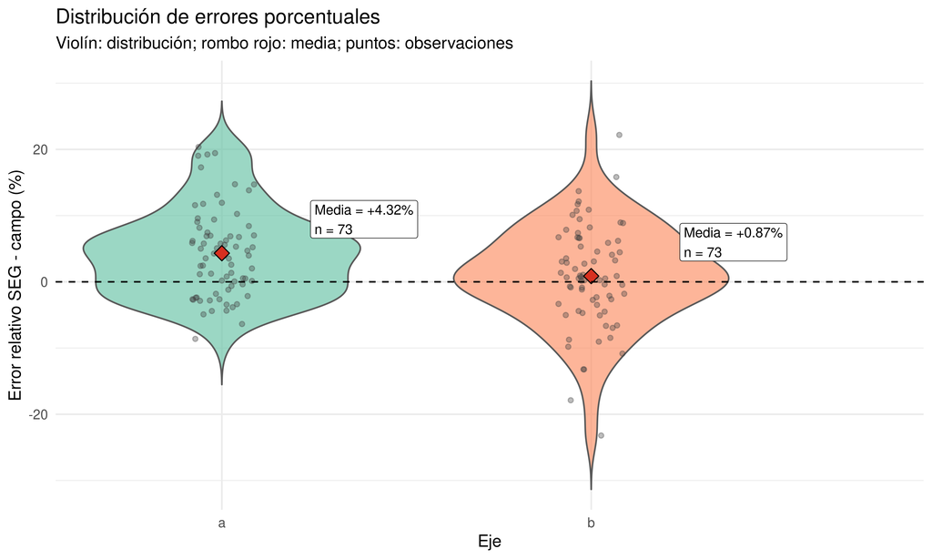

```r
guardar_csv(medias_error,'medias_error_porcentual.csv')

p_error <- ggplot(comparacion,aes(eje,error_pct,fill=eje))+
  geom_violin(trim=FALSE,alpha=.65,width=.75,color='grey35')+
  geom_jitter(width=.09,height=0,alpha=.35,size=1.5,
              color='grey25',show.legend=FALSE)+
  geom_point(data=medias_error,aes(x=eje,y=media_pct),
             inherit.aes=FALSE,shape=23,size=4,
             fill='#D7301F',color='black')+
  geom_label(data=medias_error,
             aes(x=eje,y=media_pct,label=etiqueta),
             inherit.aes=FALSE,nudge_x=.24,hjust=0,
             vjust=-.4,size=3.7,fill='white',label.size=.2)+
  geom_hline(yintercept=0,linetype='dashed')+
  scale_fill_brewer(palette='Set2',guide='none')+
  scale_x_discrete(expand=expansion(add=c(.45,.9)))+
  labs(x='Eje',y='Error relativo SEG - campo (%)',
       title='Distribución de errores porcentuales',
       subtitle='Violín: distribución; rombo rojo: media; puntos: observaciones')+
  tema
exportar(p_error,'14_error_porcentual',10,7)
```

# 7 6. Auditoría de valores extremos

```r
cols <- intersect(c('uid_final','id_grano','tesela','a_mm','b_mm',
                    'area_mm2','razon_ba','n_fragmentos','x_utm','y_utm'),
                  names(principal))
extremos <- principal %>% arrange(desc(a_mm)) %>%
  select(all_of(cols)) %>% head(30)
knitr::kable(head(extremos,10),digits=2)
```

| uid_final | id_grano | tesela | a_mm | b_mm | area_mm2 | razon_ba | n_fragmentos | x_utm | y_utm |
| --- | --- | --- | --- | --- | --- | --- | --- | --- | --- |
| 238 | x13440_y01792_g00008 | x13440_y01792 | 1723 | 1316.4 | 1747110 | 0.76 | 51 | 371870 | 2057664 |
| 266 | x22400_y05376_g00040 | x22400_y05376 | 1444 | 726.4 | 787295 | 0.50 | 4 | 371878 | 2057660 |
| 100 | x01792_y01792_g00005 | x01792_y01792 | 1282 | 971.7 | 876672 | 0.76 | 33 | 371858 | 2057663 |
| 235 | x17920_y05376_g00045 | x17920_y05376 | 1251 | 775.8 | 728643 | 0.62 | 8 | 371874 | 2057660 |
| 197 | x13440_y04480_g00001 | x13440_y04480 | 1180 | 1128.3 | 1040433 | 0.96 | 39 | 371869 | 2057661 |
| 271 | x10752_y06272_g00010 | x10752_y06272 | 1125 | 963.0 | 760904 | 0.86 | 19 | 371866 | 2057659 |
| 53 | x08064_y13440_g00003 | x08064_y13440 | 1124 | 880.0 | 764982 | 0.78 | 23 | 371863 | 2057652 |
| 203 | x19712_y12544_g00003 | x19712_y12544 | 1109 | 1007.8 | 757915 | 0.91 | 22 | 371875 | 2057653 |
| 172 | x16128_y07168_g00018 | x16128_y07168 | 1090 | 880.8 | 733900 | 0.81 | 6 | 371872 | 2057658 |
| 73 | x09856_y13440_g00052 | x09856_y13440 | 1090 | 761.5 | 641538 | 0.70 | 5 | 371865 | 2057652 |

```r
guardar_csv(extremos,'30_mayores_clastos_revisar.csv')
alertas <- principal %>% mutate(alerta=case_when(
  !is.finite(circularidad)|circularidad<=0|circularidad>1.02 ~
    'circularidad_anomala',
  a_mm>unname(quantile(principal$a_mm,.995)) ~ 'eje_mayor_extremo',
  TRUE ~ 'sin_alerta'))
guardar_csv(alertas %>% filter(alerta!='sin_alerta'),
            'objetos_revisar.csv')
```

Las alertas señalan candidatos para revisión visual, no errores confirmados.

# 8 7. Resumen para la presentación

```r
rv_a <- resumen_validacion %>% filter(eje=='a')
rv_b <- resumen_validacion %>% filter(eje=='b')
texto_presentacion <- sprintf(paste0(
  'A partir del inventario reconstruido se analizaron %s clastos, ',
  'de los cuales %s requirieron fusión de fragmentos. ',
  'La mediana del eje menor fue %.2f mm y la mediana b/a fue %.3f. ',
  'Se validaron %s clastos mediante mediciones de campo. ',
  'Las correlaciones campo–SEG fueron r=%.3f (eje a) y r=%.3f ',
  '(eje b), con MAE de %.2f y %.2f mm y MAPE de %.2f%% y %.2f%%, ',
  'respectivamente. Las medidas SEG son ejes de elipses ',
  'equivalentes proyectadas; las distribuciones son por conteo.'),
  format(nrow(principal),big.mark='.',trim=TRUE),
  format(sum(principal$n_fragmentos>1),big.mark='.',trim=TRUE),
  median(principal$b_mm),median(principal$razon_ba),nrow(val),
  rv_a$correlacion,rv_b$correlacion,
  rv_a$MAE_mm,rv_b$MAE_mm,rv_a$MAPE_pct,rv_b$MAPE_pct)
cat(texto_presentacion,'\n')
```

[output not shown]

```r
writeLines(texto_presentacion,
           file.path(DIR_TAB,'resumen_para_presentacion.txt'))
writeLines(texto_presentacion,
           file.path(PRESENTACION,'resumen_para_presentacion.txt'))
```

## 8.1 Figuras principales para las diapositivas

Las figuras `02_histograma_b_log`, `03_curva_acumulada`, `05_relacion_ejes`, `06_tamano_elongacion`, `07_mapa_D50`, `11_validacion_campo_SEG`, `12_correlacion_campo_SEG`, `14_error_porcentual` y `13_bland_altman` se guardan tanto en `figuras/` como en `resultados/presentacion/`, en PNG de 250 dpi y PDF vectorial. Las tablas se guardan en `tablas/` y `resultados/presentacion/`.

# 9 8. Información de sesión